# Exploratory analysis of a public 16S rRNA microbiome dataset

Umutcan Vural

2026-09-27

## Readme & Timeline

This project conducts an exploratory downstream analysis of processed 16S rRNA amplicon sequencing data from the GlobalPatterns dataset. It evaluates sequencing depth, alpha diversity, beta diversity, taxonomic composition, and differences in microbial community structure across sample types using R, phyloseq, vegan, and R Markdown

## Package installation

The code below checks whether the required packages are installed, installs missing packages where necessary, and loads them for the analysis.

```r
# Function for CRAN packages
check_and_install <- function(pkg) {
  if (!requireNamespace(pkg, quietly = TRUE)) {
    install.packages(pkg, dependencies = TRUE, quiet = TRUE)
  }
}

# CRAN packages used in this report
cran_packages <- c(
  "tidyverse",
  "vegan",
  "ape",
  "rmarkdown",
  "knitr",
  "here",
  "janitor"
)

# Install missing CRAN packages
invisible(lapply(cran_packages, check_and_install))

# Install Bioconductor package manager if necessary
if (!requireNamespace("BiocManager", quietly = TRUE)) {
  install.packages("BiocManager", quiet = TRUE)
}

# Install missing Bioconductor packages
bioc_packages <- c(
  "phyloseq",
  "microbiome"
)

for (pkg in bioc_packages) {
  if (!requireNamespace(pkg, quietly = TRUE)) {
    BiocManager::install(pkg, ask = FALSE, update = FALSE)
  }
}

# Load packages used in the report
invisible(lapply(
  c(cran_packages, bioc_packages),
  library,
  character.only = TRUE
))
```

## Package checking (Later)

```r
required_packages <- c(
  "tidyverse",
  "vegan",
  "janitor",
  "here",
  "phyloseq"
)

missing_packages <- required_packages[
  !vapply(required_packages, requireNamespace, logical(1), quietly = TRUE)
]

if (length(missing_packages) > 0) {
  stop(
    "Missing packages: ",
    paste(missing_packages, collapse = ", "),
    ". Please install them before rendering the report."
  )
}

invisible(lapply(required_packages, library, character.only = TRUE))
```

## Required packages

- **tidyverse**: Provides tools for importing, cleaning, transforming, summarising, and visualising tabular data, including `dplyr`, `readr`, `tidyr`, and `ggplot2`.
- **phyloseq**: Integrates microbiome abundance data, taxonomy, phylogenetic information, and sample metadata into a single object for ecological analysis.
- **vegan**: Provides ecological statistics, including Bray–Curtis dissimilarity calculations, ordination support, and PERMANOVA.
- **microbiome**: Provides microbiome-specific functions for abundance transformation, prevalence filtering, and community composition analysis.
- **ape**: Provides functions for reading, handling, and analysing phylogenetic trees when a tree is included in the dataset.
- **janitor**: Provides convenient functions for cleaning and standardising variable and column names.
- **here**: Creates reliable relative file paths within the project folder, improving reproducibility across computers.
- **rmarkdown**: Renders the analysis, code, figures, and written interpretation into a reproducible HTML report.
- **knitr**: Executes R code chunks and formats code, tables, figures, and output inside the R Markdown report.

# Introduction and Research Question

**Research question:**

> How do microbial alpha diversity, beta diversity, and taxonomic composition vary across environmental and host-associated sample types in the GlobalPatterns dataset?

Microbial communities differ substantially depending on the environment or host they are associated with. This analysis explores whether samples from different environmental and host-associated sources (e.g., soil, ocean, feces, skin) differ in:

- **Alpha diversity** — diversity *within* a sample (richness/evenness)
- **Beta diversity** — diversity *between* samples (community structure)
- **Taxonomic composition** — which taxa dominate each sample type

# Dataset Description

`GlobalPatterns` is a widely used example 16S rRNA amplicon dataset distributed with the `phyloseq` package (Caporaso et al. 2011). It contains high-throughput sequencing data from 26 samples spanning diverse environmental and host-associated sources, along with an associated phylogenetic tree and taxonomy assignments.

# Package Setup

```r
library(tidyverse)
library(phyloseq)
library(vegan)
library(ape)
library(rmarkdown)
```

# Load GlobalPatterns

```r
data(GlobalPatterns)
GlobalPatterns
```

```
## phyloseq-class experiment-level object
## otu_table()   OTU Table:         [ 19216 taxa and 26 samples ]
## sample_data() Sample Data:       [ 26 samples by 7 sample variables ]
## tax_table()   Taxonomy Table:    [ 19216 taxa by 7 taxonomic ranks ]
## phy_tree()    Phylogenetic Tree: [ 19216 tips and 19215 internal nodes ]
```

# Inspect Data Structure

```r
ntaxa(GlobalPatterns)
```

```
## [1] 19216
```

```r
nsamples(GlobalPatterns)
```

```
## [1] 26
```

```r
rank_names(GlobalPatterns)
```

```
## [1] "Kingdom" "Phylum"  "Class"   "Order"   "Family"  "Genus"   "Species"
```

```r
# Zero-count taxa (candidates for filtering later)
sum(taxa_sums(GlobalPatterns) == 0)
```

```
## [1] 228
```

```r
# Any missing values in the OTU table?
any(is.na(otu_table(GlobalPatterns)))
```

```
## [1] FALSE
```

# Inspect Sample Metadata

```r
sample_data(GlobalPatterns) %>%
  as("data.frame") %>%
  glimpse()
```

```
## Rows: 26
## Columns: 7
## $ X.SampleID               <fct> CL3, CC1, SV1, M31Fcsw, M11Fcsw, M31Plmr, M11…
## $ Primer                   <fct> ILBC_01, ILBC_02, ILBC_03, ILBC_04, ILBC_05, …
## $ Final_Barcode            <fct> AACGCA, AACTCG, AACTGT, AAGAGA, AAGCTG, AATCG…
## $ Barcode_truncated_plus_T <fct> TGCGTT, CGAGTT, ACAGTT, TCTCTT, CAGCTT, ACGAT…
## $ Barcode_full_length      <fct> CTAGCGTGCGT, CATCGACGAGT, GTACGCACAGT, TCGACA…
## $ SampleType               <fct> Soil, Soil, Soil, Feces, Feces, Skin, Skin, S…
## $ Description              <fct> "Calhoun South Carolina Pine soil, pH 4.9", "…
```

```r
# Sample types available for grouping in later analyses
sample_data(GlobalPatterns)$SampleType %>% unique()
```

```
## [1] Soil               Feces              Skin               Tongue
## [5] Freshwater         Freshwater (creek) Ocean              Sediment (estuary)
## [9] Mock
## 9 Levels: Feces Freshwater Freshwater (creek) Mock ... Tongue
```

```r
# Sample count per SampleType
sample_data(GlobalPatterns) %>%
  as("data.frame") %>%
  count(SampleType, sort = TRUE)
```

```
##           SampleType n
## 1              Feces 4
## 2 Freshwater (creek) 3
## 3               Mock 3
## 4              Ocean 3
## 5 Sediment (estuary) 3
## 6               Skin 3
## 7               Soil 3
## 8         Freshwater 2
## 9             Tongue 2
```

# Sequencing-Depth Assessment

Sequencing depth (library size = total reads per sample) varies naturally across samples and sample types. Low-depth samples can artificially deflate alpha diversity estimates and distort beta diversity distances, so we inspect depth here before deciding on any filtering or exclusion.

```r
# Build a depth table: one row per sample, with SampleType attached
depth_df <- tibble(
  SampleID   = sample_names(GlobalPatterns),
  LibSize    = sample_sums(GlobalPatterns),
  SampleType = sample_data(GlobalPatterns)$SampleType
)

depth_df %>% arrange(LibSize)
```

```
## # A tibble: 26 × 3
##    SampleID LibSize SampleType
##    <chr>      <dbl> <fct>
##  1 TRRsed1    58688 Sediment (estuary)
##  2 M11Tong   100187 Tongue
##  3 F21Plmr   186297 Skin
##  4 TRRsed3   279704 Sediment (estuary)
##  5 M11Plmr   433894 Skin
##  6 TRRsed2   493126 Sediment (estuary)
##  7 NP2       523634 Ocean
##  8 SV1       697509 Soil
##  9 M31Plmr   718943 Skin
## 10 CL3       864077 Soil
## # ℹ 16 more rows
```

```r
# Numeric summary overall
summary(depth_df$LibSize)
```

```
##    Min. 1st Qu.  Median    Mean 3rd Qu.    Max.
##   58688  567103 1106849 1085257 1527330 2357181
```

```r
# Numeric summary by SampleType
depth_df %>%
  group_by(SampleType) %>%
  summarise(
    n      = n(),
    min    = min(LibSize),
    median = median(LibSize),
    mean   = mean(LibSize),
    max    = max(LibSize),
    .groups = "drop"
  ) %>%
  arrange(median)
```

```
## # A tibble: 9 × 6
##   SampleType             n     min   median     mean     max
##   <fct>              <int>   <dbl>    <dbl>    <dbl>   <dbl>
## 1 Sediment (estuary)     3   58688  279704   277173.  493126
## 2 Skin                   3  186297  433894   446378   718943
## 3 Soil                   3  697509  864077   899014. 1135457
## 4 Tongue                 2  100187 1050294. 1050294. 2000402
## 5 Mock                   3  971073 1078241  1088484. 1216137
## 6 Feces                  4  937466 1377261  1442116  2076476
## 7 Ocean                  3  523634 1478965  1218451  1652754
## 8 Freshwater             2 1217312 1667452  1667452  2117592
## 9 Freshwater (creek)     3 1167748 1699293  1741407. 2357181
```

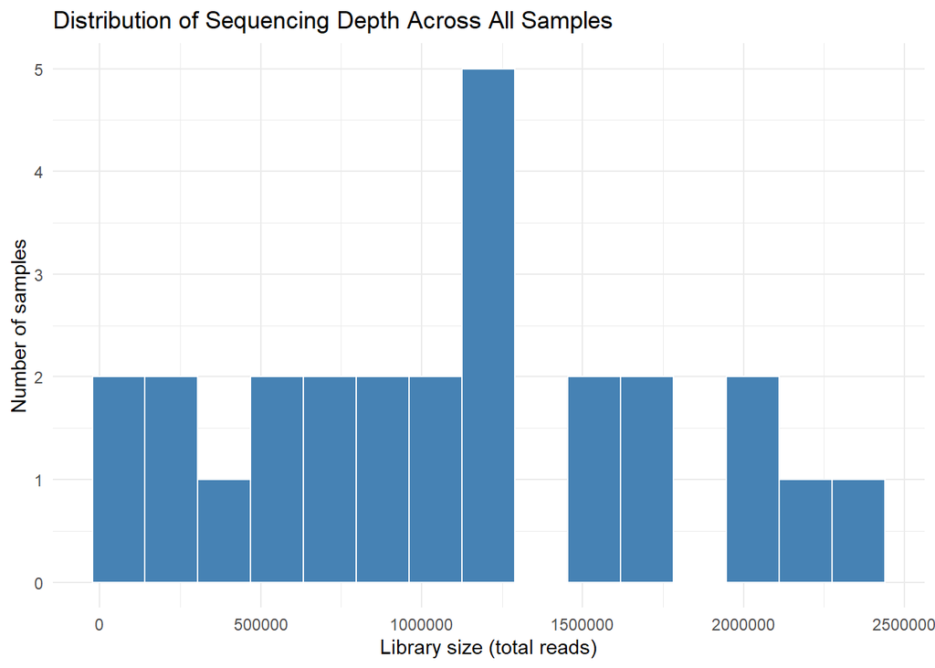

```r
ggplot(depth_df, aes(x = LibSize)) +
  geom_histogram(bins = 15, fill = "steelblue", color = "white") +
  labs(
    title = "Distribution of Sequencing Depth Across All Samples",
    x = "Library size (total reads)",
    y = "Number of samples"
  ) +
  theme_minimal()
```

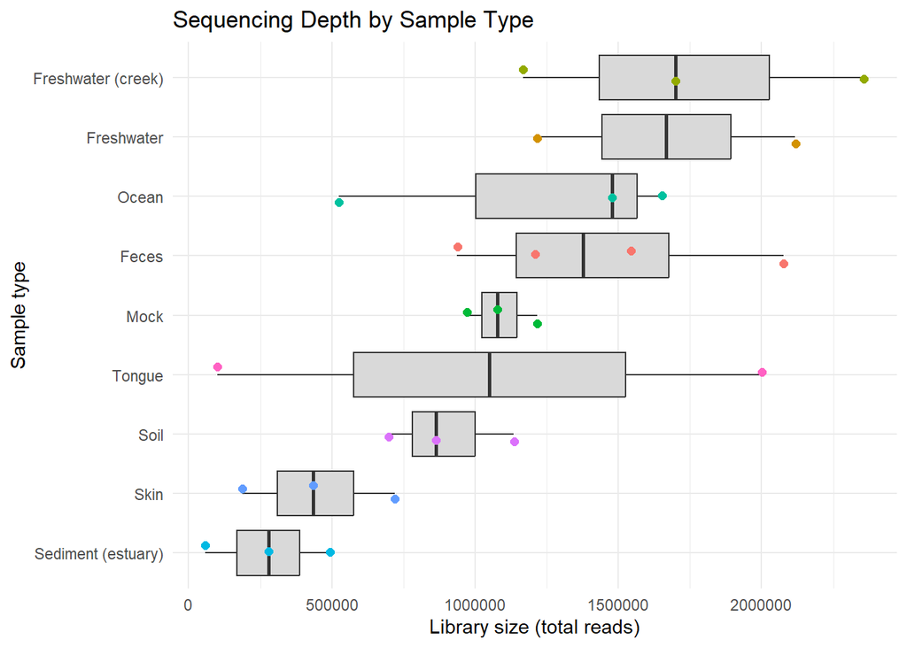

```r
ggplot(depth_df, aes(x = reorder(SampleType, LibSize, median), y = LibSize)) +
  geom_boxplot(outlier.shape = NA, fill = "grey85") +
  geom_jitter(aes(color = SampleType), width = 0.15, size = 2, show.legend = FALSE) +
  coord_flip() +
  labs(
    title = "Sequencing Depth by Sample Type",
    x = "Sample type",
    y = "Library size (total reads)"
  ) +
  theme_minimal()
```

```r
# Flag samples below the 10th percentile of overall library size as a
# starting heuristic; adjust threshold after visual inspection above.
low_depth_threshold <- quantile(depth_df$LibSize, 0.10)

depth_df %>%
  filter(LibSize < low_depth_threshold) %>%
  arrange(LibSize)
```

```
## # A tibble: 3 × 3
##   SampleID LibSize SampleType
##   <chr>      <dbl> <fct>
## 1 TRRsed1    58688 Sediment (estuary)
## 2 M11Tong   100187 Tongue
## 3 F21Plmr   186297 Skin
```

```r
# Check for natural gaps / isolated low-depth failures by looking at the
# ratio between each sample and the next-lowest one, once sorted by depth.
depth_df %>%
  arrange(LibSize) %>%
  mutate(
    PreviousDepth   = lag(LibSize),
    RatioToPrevious = LibSize / PreviousDepth
  )
```

```
## # A tibble: 26 × 5
##    SampleID LibSize SampleType         PreviousDepth RatioToPrevious
##    <chr>      <dbl> <fct>                      <dbl>           <dbl>
##  1 TRRsed1    58688 Sediment (estuary)            NA           NA
##  2 M11Tong   100187 Tongue                     58688            1.71
##  3 F21Plmr   186297 Skin                      100187            1.86
##  4 TRRsed3   279704 Sediment (estuary)        186297            1.50
##  5 M11Plmr   433894 Skin                      279704            1.55
##  6 TRRsed2   493126 Sediment (estuary)        433894            1.14
##  7 NP2       523634 Ocean                     493126            1.06
##  8 SV1       697509 Soil                      523634            1.33
##  9 M31Plmr   718943 Skin                      697509            1.03
## 10 CL3       864077 Soil                      718943            1.20
## # ℹ 16 more rows
```

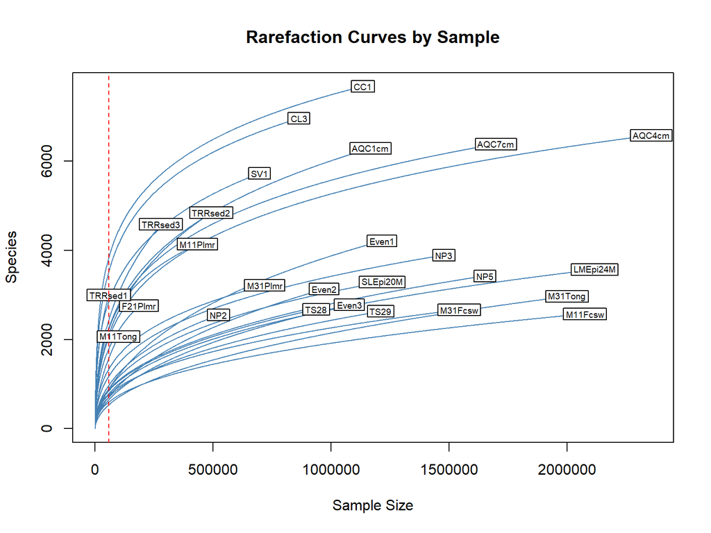

```r
# Rarefaction curves: if a sample's curve plateaus well before its total
# depth, its diversity estimate is not depth-limited. If curves for
# low-depth samples end while still rising steeply, that IS a depth-driven
# failure signal (unlike a simple ratio/threshold check).
otu_mat <- as(otu_table(GlobalPatterns), "matrix")
if (taxa_are_rows(GlobalPatterns)) otu_mat <- t(otu_mat)

rarecurve(
  otu_mat,
  step      = 1000,
  label     = TRUE,
  cex       = 0.6,
  col       = "steelblue",
  main      = "Rarefaction Curves by Sample"
)
abline(v = min(depth_df$LibSize), col = "red", lty = 2)
```

The dashed red line marks the minimum observed library size (58,688 reads — `TRRsed1`). Note that `TRRsed1`’s curve necessarily *ends* at this line since it is the minimum-depth sample — that alone is not informative. What matters is the **slope** of each curve near its endpoint: a flat slope means the sample was sequenced deeply enough to capture most of its richness; a steep slope means richness was still being discovered when sequencing stopped (i.e., the sample is under-saturated).

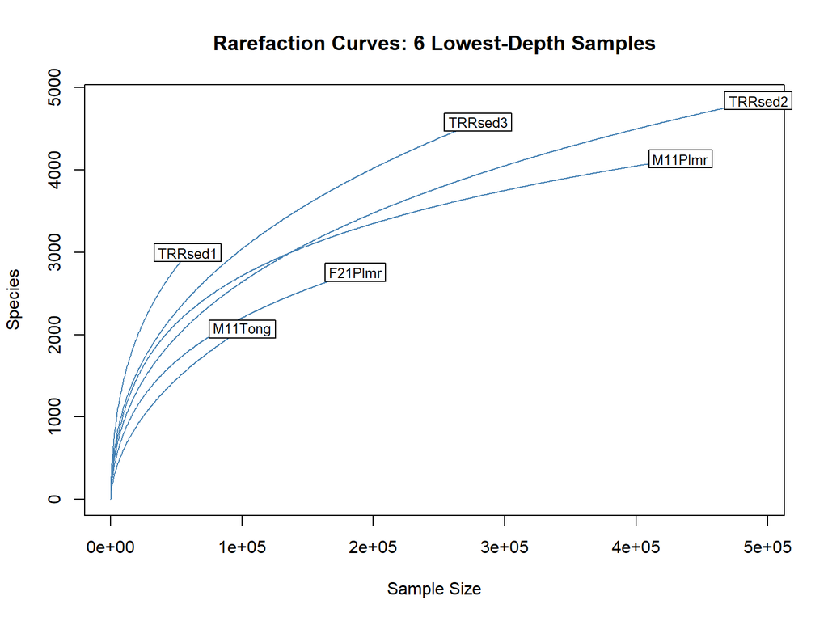

```r
# Zoom in on the lowest-depth samples only, so the slope near each curve's
# endpoint can actually be judged (the full 26-sample plot is too compressed
# to read this reliably).
low_depth_samples <- depth_df %>%
  arrange(LibSize) %>%
  slice_head(n = 6) %>%
  pull(SampleID)

rarecurve(
  otu_mat[low_depth_samples, ],
  step  = 500,
  label = TRUE,
  cex   = 0.8,
  col   = "steelblue",
  main  = "Rarefaction Curves: 6 Lowest-Depth Samples"
)
```

> **Observed result:** on visual inspection, the curves for the lowest-depth samples (including `TRRsed1`, the minimum-depth sample) were **still rising, not flattened**, at their endpoint. This confirms under-saturation for at least the lowest-depth samples in the dataset. Absolute richness values from the rarefied table (section 9) should therefore be treated as **conservative lower bounds** rather than saturated estimates — a point carried forward into section 13 (Interpretation and Limitations).

# Filtering Decision

### Decision on low-depth samples

Samples were ranked by library size and inspected for natural gaps or isolated low-depth failures using ratio-to-previous comparisons and rarefaction curves. No sample was separated from its neighbors by a disproportionate gap; depth increased smoothly across the full range (58,688–2,357,181 reads), and the three samples flagged below the 10th percentile (58,688–186,297 reads) sit on this same continuous gradient rather than forming an isolated cluster of failures. Rarefaction curves for the lowest-depth samples had not clearly plateaued by their endpoint, indicating these samples are somewhat under-saturated and their true richness may be underestimated. This is a limitation of the data rather than a reason for exclusion: rarefying **all** samples to the shared minimum depth (section 9) still yields diversity estimates that are directly comparable across samples, even though those estimates will be conservative (i.e., true richness for all samples, not just the low-depth ones, is likely somewhat higher than the rarefied estimate).

A hard threshold of 50,000 reads was considered; since the minimum observed library size (58,688 reads, `TRRsed1`) is already above this threshold, no samples would be removed under this rule. Combined with the small existing group sizes for several `SampleType` levels (n = 2–3), excluding any sample would materially reduce statistical power in later group comparisons (alpha-diversity tests, PERMANOVA) for negligible benefit.

**All 26 samples are retained.** Sequencing-depth variation is instead addressed methodologically: alpha diversity is computed on a rarefied table (section 9), and beta diversity is computed on relative-abundance (proportion) data (section 10), rather than by dropping samples.

### Taxon-level filtering

Separately from sample filtering, taxa with zero counts across all samples add no information and are removed before downstream analysis.

```r
# Remove taxa with zero total counts across all samples
GlobalPatterns_filt <- prune_taxa(taxa_sums(GlobalPatterns) > 0, GlobalPatterns)

ntaxa(GlobalPatterns)       # before
```

```
## [1] 19216
```

```r
ntaxa(GlobalPatterns_filt)  # after
```

```
## [1] 18988
```

```r
before <- ntaxa(GlobalPatterns)
after  <- ntaxa(GlobalPatterns_filt)

percent_removed <- (before - after) / before * 100
percent_retained <- after / before * 100
percent_removed
```

```
## [1] 1.186511
```

```r
percent_retained
```

```
## [1] 98.81349
```

### Prepare normalized objects for downstream analysis

```r
set.seed(123)  # reproducibility for rarefaction

# 1. Rarefied object -> for alpha diversity (section 9)
#    Rarefies every sample to the minimum observed depth so richness/
#    Shannon are compared on an equal footing.
GlobalPatterns_rare <- rarefy_even_depth(
  GlobalPatterns_filt,
  sample.size = min(sample_sums(GlobalPatterns_filt)),
  rngseed     = 123,
  replace     = FALSE,
  verbose     = FALSE
)

ntaxa(GlobalPatterns_rare)
```

```
## [1] 12840
```

```r
sample_sums(GlobalPatterns_rare) %>% unique()  # should all equal min depth
```

```
## [1] 58688
```

```r
# 2. Relative-abundance object -> for beta diversity / PCoA (section 10)
#    Converts counts to proportions per sample, avoiding the need to
#    discard reads via rarefaction for ordination-based comparisons.
GlobalPatterns_relabund <- transform_sample_counts(
  GlobalPatterns_filt,
  function(x) x / sum(x)
)

sample_sums(GlobalPatterns_relabund) %>% unique()  # should all equal 1
```

```
## [1] 1
```

# Alpha diversity

How diverse is each individual microbiome sample?

Alpha diversity describes the diversity within an individual microbiome sample. This analysis uses the rarefied feature table, in which all samples contain the same number of feature counts, to reduce the influence of unequal sequencing depth.

Two metrics are examined:

- **Observed richness**: the number of observed microbial features in a sample.
- **Shannon diversity**: a measure that reflects both the number of features and the evenness of their relative abundances.

```r
alpha_diversity <- estimate_richness(
  GlobalPatterns_rare,
  measures = c("Observed", "Shannon", "Simpson")
) |>
  tibble::rownames_to_column("SampleID") |>
  left_join(
    depth_df |>
      select(SampleID, SampleType, LibSize),
    by = "SampleID"
  )

alpha_diversity
```

```
##    SampleID Observed  Shannon   Simpson         SampleType LibSize
## 1       CL3     3555 6.523026 0.9945306               Soil  864077
## 2       CC1     3857 6.723098 0.9951734               Soil 1135457
## 3       SV1     2848 6.462136 0.9962425               Soil  697509
## 4   M31Fcsw      758 3.811084 0.9270416              Feces 1543451
## 5   M11Fcsw      589 3.279804 0.9106837              Feces 2076476
## 6   M31Plmr     1334 4.269331 0.9379325               Skin  718943
## 7   M11Plmr     2315 4.830150 0.9519636               Skin  433894
## 8   F21Plmr     1807 4.866082 0.9779074               Skin  186297
## 9   M31Tong      545 2.654647 0.8616103             Tongue 2000402
## 10  M11Tong     1590 3.904547 0.9364362             Tongue  100187
## 11 LMEpi24M      792 3.079271 0.8028816         Freshwater 2117592
## 12 SLEpi20M      895 3.636902 0.9069612         Freshwater 1217312
## 13   AQC1cm     2260 3.502747 0.7632103 Freshwater (creek) 1167748
## 14   AQC4cm     2043 3.341037 0.7386072 Freshwater (creek) 2357181
## 15   AQC7cm     2221 3.988752 0.8178390 Freshwater (creek) 1699293
## 16      NP2      990 4.216211 0.9531651              Ocean  523634
## 17      NP3     1157 4.447797 0.9716424              Ocean 1478965
## 18      NP5      869 4.552264 0.9747965              Ocean 1652754
## 19  TRRsed1     2995 6.157462 0.9924388 Sediment (estuary)   58688
## 20  TRRsed2     2155 4.848279 0.9645751 Sediment (estuary)  493126
## 21  TRRsed3     2438 5.428607 0.9816982 Sediment (estuary)  279704
## 22     TS28      845 4.110183 0.9653290              Feces  937466
## 23     TS29      708 3.441169 0.9185227              Feces 1211071
## 24    Even1      879 4.065167 0.9682462               Mock 1216137
## 25    Even2      718 3.934744 0.9635913               Mock  971073
## 26    Even3      651 3.995106 0.9672839               Mock 1078241
```

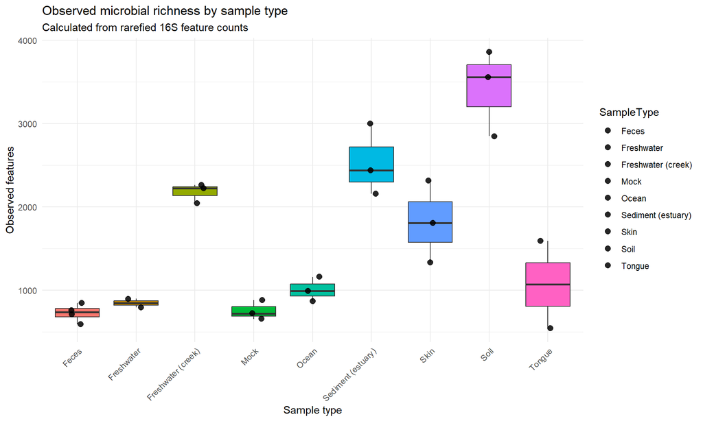

```r
ggplot(
  alpha_diversity,
  aes(x = SampleType, y = Observed, fill = SampleType)
) +
  geom_boxplot(show.legend = FALSE, outlier.shape = NA) +
  geom_jitter(width = 0.15, size = 2.5, alpha = 0.85) +
  labs(
    title = "Observed microbial richness by sample type",
    subtitle = "Calculated from rarefied 16S feature counts",
    x = "Sample type",
    y = "Observed features"
  ) +
  theme_minimal() +
  theme(
    axis.text.x = element_text(angle = 45, hjust = 1)
  )
```

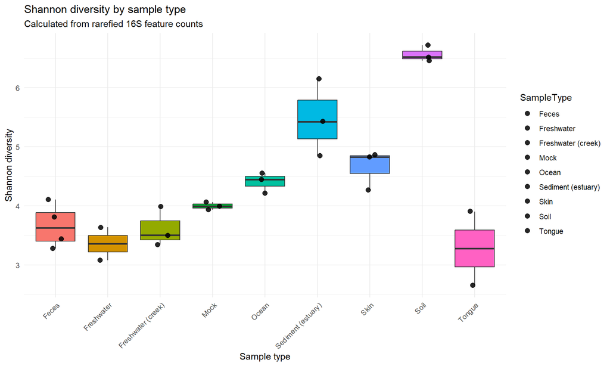

```r
ggplot(
  alpha_diversity,
  aes(x = SampleType, y = Shannon, fill = SampleType)
) +
  geom_boxplot(show.legend = FALSE, outlier.shape = NA) +
  geom_jitter(width = 0.15, size = 2.5, alpha = 0.85) +
  labs(
    title = "Shannon diversity by sample type",
    subtitle = "Calculated from rarefied 16S feature counts",
    x = "Sample type",
    y = "Shannon diversity"
  ) +
  theme_minimal() +
  theme(
    axis.text.x = element_text(angle = 45, hjust = 1)
  )
```

```r
alpha_summary <- alpha_diversity |>
  group_by(SampleType) |>
  summarise(
    Samples = n(),
    MedianObserved = median(Observed),
    MedianShannon = median(Shannon),
    MedianSimpson = median(Simpson),
    .groups = "drop"
  ) |>
  arrange(desc(MedianShannon))

alpha_summary
```

```
## # A tibble: 9 × 5
##   SampleType         Samples MedianObserved MedianShannon MedianSimpson
##   <fct>                <int>          <dbl>         <dbl>         <dbl>
## 1 Soil                     3          3555           6.52         0.995
## 2 Sediment (estuary)       3          2438           5.43         0.982
## 3 Skin                     3          1807           4.83         0.952
## 4 Ocean                    3           990           4.45         0.972
## 5 Mock                     3           718           4.00         0.967
## 6 Feces                    4           733           3.63         0.923
## 7 Freshwater (creek)       3          2221           3.50         0.763
## 8 Freshwater               2           844.          3.36         0.855
## 9 Tongue                   2          1068.          3.28         0.899
```

### Statistical test

Group sizes are small and unequal (n = 2-4) and diversity indices are not guaranteed to be normally distributed, so a non-parametric Kruskal-Wallis test is used rather than ANOVA to test for overall differences in each metric across `SampleType`.

```r
kruskal.test(Observed ~ SampleType, data = alpha_diversity)
```

```
##
##  Kruskal-Wallis rank sum test
##
## data:  Observed by SampleType
## Kruskal-Wallis chi-squared = 21.33, df = 8, p-value = 0.006319
```

```r
kruskal.test(Shannon  ~ SampleType, data = alpha_diversity)
```

```
##
##  Kruskal-Wallis rank sum test
##
## data:  Shannon by SampleType
## Kruskal-Wallis chi-squared = 22.125, df = 8, p-value = 0.004689
```

```r
kruskal.test(Simpson  ~ SampleType, data = alpha_diversity)
```

```
##
##  Kruskal-Wallis rank sum test
##
## data:  Simpson by SampleType
## Kruskal-Wallis chi-squared = 21.416, df = 8, p-value = 0.006121
```

**Result:** all three tests were significant (Observed: χ² = 21.33, df = 8, p = 0.0063; Shannon: χ² = 22.13, df = 8, p = 0.0047; Simpson: χ² = 21.42, df = 8, p = 0.0061). Alpha diversity differs significantly across `SampleType`, consistent with the pattern observed above — Soil showing the highest diversity and Feces/Mock/Tongue among the lowest. This is a group-level difference, not a statement about the dataset as a whole: diversity is a per-group property, and a non-significant result here would simply have meant the groups were similarly diverse, not that the data were flawed.

With only 2–4 samples per group, these tests have limited power; a non-significant result should be interpreted as inconclusive rather than as evidence of no difference. The significant omnibus result confirms *some* group differs from others, but not *which* specific pairs — a post-hoc test (e.g., Dunn’s test) would be needed for pairwise claims, which is beyond the current scope but noted as a possible extension.

# Beta diversity/PCoA

Beta diversity describes differences in microbial community composition between samples. Bray–Curtis dissimilarity is calculated from the **relative-abundance** table (`GlobalPatterns_relabund`), not the rarefied table, per the decision in section 8: rarefying a second time would discard additional reads for no benefit, whereas converting to proportions controls for uneven sequencing depth while retaining all observed taxa. Principal Coordinates Analysis (PCoA) is used to visualise the resulting between-sample relationships.

```r
bray_dist <- phyloseq::distance(GlobalPatterns_relabund, method = "bray")

# Quick check: distance matrix dimensions should match sample count
as.matrix(bray_dist) %>% dim()
```

```
## [1] 26 26
```

```r
pcoa_ord <- ordinate(GlobalPatterns_relabund, method = "PCoA", distance = bray_dist)

# Variance explained by each axis
pcoa_eig <- pcoa_ord$values$Relative_eig
round(pcoa_eig[1:5] * 100, 1)  # % variance explained, axes 1-5
```

```
## [1] 14.7 12.2 10.6  9.0  8.7
```

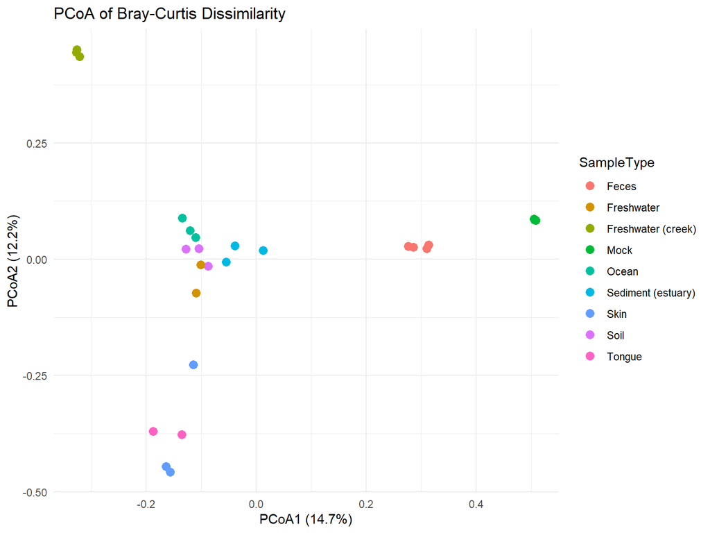

```r
plot_ordination(GlobalPatterns_relabund, pcoa_ord, color = "SampleType") +
  geom_point(size = 3) +
  labs(
    title = "PCoA of Bray-Curtis Dissimilarity",
    x = paste0("PCoA1 (", round(pcoa_eig[1] * 100, 1), "%)"),
    y = paste0("PCoA2 (", round(pcoa_eig[2] * 100, 1), "%)")
  ) +
  theme_minimal()
```

**Interpretation guide:** samples that cluster tightly together have similar community composition; samples far apart differ substantially. Environmental sample types (Soil, Sediment, Freshwater, Ocean) are expected to separate from host-associated types (Feces, Skin, Tongue) if community structure is driven primarily by habitat — this is checked visually here and tested formally in section 11 (PERMANOVA).

**Result:** Principal Coordinates Analysis was applied to the Bray–Curtis dissimilarity matrix to visualise differences in microbial community composition. The first two coordinate axes explained 14.7% and 12.2% of the observed compositional variation, respectively. Samples positioned closer together had more similar relative-abundance profiles, whereas more distant samples had more dissimilar profiles. Together, PCoA1 and PCoA2 account for only ~27% of total variance, so the two-dimensional plot is a useful summary but does not capture the full complexity of community differences — this is normal for compositional data with many taxa and is not a sign of a failed ordination.

# PERMANOVA

The PCoA plot shows *where* samples fall relative to each other, but not whether apparent clustering by `SampleType` is statistically significant. PERMANOVA (Permutational Multivariate Analysis of Variance, `adonis2()`) tests this directly: it asks whether Bray–Curtis distances *within* the same `SampleType` are smaller than distances *between* different `SampleType` groups, more than would be expected by chance.

```r
set.seed(123)  # reproducibility for permutation test

sample_df <- sample_data(GlobalPatterns_relabund) %>% as("data.frame")

permanova_result <- adonis2(
  bray_dist ~ SampleType,
  data        = sample_df,
  permutations = 999
)

permanova_result
```

```
## Permutation test for adonis under reduced model
## Permutation: free
## Number of permutations: 999
##
## adonis2(formula = bray_dist ~ SampleType, data = sample_df, permutations = 999)
##          Df SumOfSqs      R2      F Pr(>F)
## Model     8   8.2466 0.73109 5.7773  0.001 ***
## Residual 17   3.0332 0.26891
## Total    25  11.2798 1.00000
## ---
## Signif. codes:  0 '***' 0.001 '**' 0.01 '*' 0.05 '.' 0.1 ' ' 1
```

**Interpretation guide:** the `R2` column shows the proportion of total community-composition variance explained by `SampleType`; the `p-value` column tests whether this is greater than expected by chance, based on 999 random permutations of group labels.

### Checking the PERMANOVA assumption

PERMANOVA assumes similar within-group dispersion (spread) across groups; if dispersion differs substantially, a significant PERMANOVA result could reflect differences in spread rather than differences in group centroids (mean composition). This is checked with `betadisper()`.

```r
dispersion <- betadisper(bray_dist, sample_df$SampleType)
anova(dispersion)
```

```
## Analysis of Variance Table
##
## Response: Distances
##           Df  Sum Sq  Mean Sq F value   Pr(>F)
## Groups     8 0.49965 0.062457  5.8071 0.001158 **
## Residuals 17 0.18284 0.010755
## ---
## Signif. codes:  0 '***' 0.001 '**' 0.01 '*' 0.05 '.' 0.1 ' ' 1
```

If this dispersion test is **not** significant, it supports interpreting the PERMANOVA result above as reflecting genuine differences in community composition between sample types, rather than an artifact of unequal within-group variability. If it **is** significant, the PERMANOVA result should be interpreted more cautiously alongside the PCoA plot.

As with the alpha-diversity tests, small and unequal group sizes (n = 2–4) limit statistical power here; results should be interpreted as suggestive evidence for this specific dataset rather than strong confirmatory inference.

**Result:** PERMANOVA found that `SampleType` explains a large proportion of total community variance (R² = 0.731, F = 5.78, p = 0.001), indicating that sample type is a dominant driver of compositional differences in this dataset. However, the dispersion test was also significant (F = 5.81, p = 0.00116), meaning groups differ in within-group spread as well as in centroid location. This means the PERMANOVA result is not fully clean: part of the 73.1% variance explained could reflect unequal dispersion rather than pure differences in group composition. An effect size this large is unlikely to be *entirely* a dispersion artifact, so genuine compositional differences between sample types almost certainly exist — but R² = 0.731 should be treated as an upper-bound estimate rather than a precise one.

**Note:** Some sample types form tight clusters: their replicate communities are quite similar to one another. Other sample types form wide clouds: their replicate communities differ more from one another.

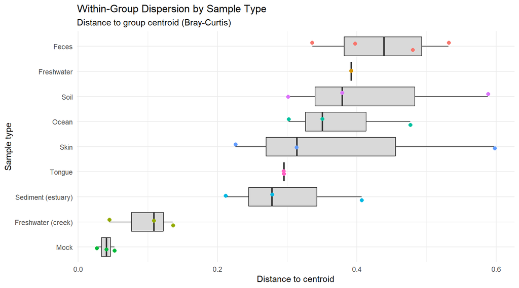

```r
dispersion_df <- tibble(
  SampleID   = names(dispersion$distances),
  Distance   = dispersion$distances,
  SampleType = sample_df$SampleType
)

ggplot(dispersion_df, aes(x = reorder(SampleType, Distance, median), y = Distance)) +
  geom_boxplot(fill = "grey85", outlier.shape = NA) +
  geom_jitter(aes(color = SampleType), width = 0.15, size = 2, show.legend = FALSE) +
  coord_flip() +
  labs(
    title = "Within-Group Dispersion by Sample Type",
    subtitle = "Distance to group centroid (Bray-Curtis)",
    x = "Sample type",
    y = "Distance to centroid"
  ) +
  theme_minimal()
```

This plot identifies which groups are driving the significant dispersion result. With only 2–4 points per group, the boxplots themselves are hard to read reliably — a numeric summary is more informative here.

**Interpretation guide:** Small distance → samples within that group are similar to each other → tight group / low within-group heterogeneity Large distance → samples within that group vary more from one another → spread-out group / high within-group heterogeneity

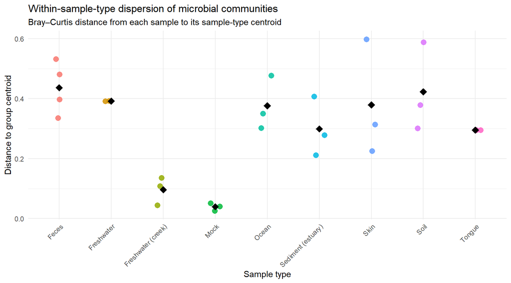

```r
dispersion_df <- data.frame(
  SampleType = sample_df$SampleType,
  DistanceToCentroid = dispersion$distances
)

ggplot(
  dispersion_df,
  aes(x = SampleType, y = DistanceToCentroid, colour = SampleType)
) +
  geom_jitter(width = 0.12, size = 3, alpha = 0.85, show.legend = FALSE) +
  stat_summary(
    fun = mean,
    geom = "point",
    shape = 18,
    size = 4,
    colour = "black"
  ) +
  labs(
    title = "Within-sample-type dispersion of microbial communities",
    subtitle = "Bray–Curtis distance from each sample to its sample-type centroid",
    x = "Sample type",
    y = "Distance to group centroid"
  ) +
  theme_minimal() +
  theme(
    axis.text.x = element_text(angle = 45, hjust = 1)
  )
```

```r
dispersion_df %>%
  group_by(SampleType) %>%
  summarise(
    n              = n(),
    MedianDistance = median(DistanceToCentroid),
    MinDistance    = min(DistanceToCentroid),
    MaxDistance    = max(DistanceToCentroid),
    Range          = MaxDistance - MinDistance,
    .groups = "drop"
  ) %>%
  arrange(desc(MedianDistance))
```

```
## # A tibble: 9 × 6
##   SampleType             n MedianDistance MinDistance MaxDistance    Range
##   <fct>              <int>          <dbl>       <dbl>       <dbl>    <dbl>
## 1 Feces                  4         0.439       0.336       0.532  1.96e- 1
## 2 Freshwater             2         0.392       0.392       0.392  0
## 3 Soil                   3         0.379       0.301       0.588  2.87e- 1
## 4 Ocean                  3         0.350       0.302       0.477  1.75e- 1
## 5 Skin                   3         0.314       0.226       0.598  3.72e- 1
## 6 Tongue                 2         0.295       0.295       0.295  5.55e-17
## 7 Sediment (estuary)     3         0.278       0.212       0.407  1.95e- 1
## 8 Freshwater (creek)     3         0.108       0.0449      0.136  9.10e- 2
## 9 Mock                   3         0.0405      0.0265      0.0520 2.55e- 2
```

This table shows which sample types actually have the largest and smallest distance-to-centroid values, rather than relying on a visual read of boxplots that are hard to interpret with so few points per group. The pattern here — not an assumption about group size — is what should drive the interpretation of the dispersion test above.

**Result:** `Freshwater` and `Tongue` (both n = 2) show a Range of essentially zero. This is a mathematical property of n = 2 groups, not a biological finding — with only two samples, both points are always exactly equidistant from their own group’s centroid (the centroid *is* their midpoint). These two groups therefore contribute no real information about biological dispersion and should be excluded from any claim about which sample types are “tightly clustered.”

# Taxonomic composition

To visualise which microbial groups contribute to differences among sample types, feature-level relative abundances were aggregated to the phylum level and plotted as stacked bar charts. For clarity, only the ten most abundant phyla are shown individually; remaining phyla are grouped as “Other.”

```r
# Agglomerate to phylum level
ps_phylum <- tax_glom(GlobalPatterns_relabund, taxrank = "Phylum")

tax_df <- as.data.frame(tax_table(ps_phylum)) %>%
  rownames_to_column("OTU")

# Determine the 10 most abundant phyla by mean relative abundance.
# IMPORTANT: taxa_sums() names are OTU IDs, not phylum names, so they
# must be resolved via tax_df before comparing against the Phylum column.
phylum_means <- taxa_sums(ps_phylum) / nsamples(ps_phylum)
top10_otu    <- names(sort(phylum_means, decreasing = TRUE))[1:10]
top10_phyla  <- tax_df$Phylum[match(top10_otu, tax_df$OTU)] %>% as.character()

top10_phyla  # sanity check: should be 10 readable phylum names, e.g. "p__Bacteroidetes"
```

```
##  [1] "Proteobacteria"  "Firmicutes"      "Bacteroidetes"   "Cyanobacteria"
##  [5] "Actinobacteria"  "Verrucomicrobia" "Acidobacteria"   "Planctomycetes"
##  [9] "Fusobacteria"    "Tenericutes"
```

```r
# Pull out taxonomy + abundance as a long data frame for plotting, since
# this gives explicit control over the "Other" grouping
otu_df <- as.data.frame(otu_table(ps_phylum))
if (!taxa_are_rows(ps_phylum)) otu_df <- t(otu_df)
otu_df <- otu_df %>%
  as.data.frame() %>%
  rownames_to_column("OTU") %>%
  pivot_longer(-OTU, names_to = "SampleID", values_to = "RelAbundance")

phylum_long <- otu_df %>%
  left_join(tax_df %>% select(OTU, Phylum), by = "OTU") %>%
  left_join(
    sample_data(ps_phylum) %>% as("data.frame") %>%
      rownames_to_column("SampleID") %>%
      select(SampleID, SampleType),
    by = "SampleID"
  ) %>%
  mutate(Phylum = ifelse(Phylum %in% top10_phyla, as.character(Phylum), "Other")) %>%
  group_by(SampleID, SampleType, Phylum) %>%
  summarise(RelAbundance = sum(RelAbundance), .groups = "drop")

# Sanity check: should show 11 distinct values (10 phyla + "Other"),
# not a single dominant category
phylum_long %>% count(Phylum, sort = TRUE)
```

```
## # A tibble: 11 × 2
##    Phylum              n
##    <chr>           <int>
##  1 Acidobacteria      26
##  2 Actinobacteria     26
##  3 Bacteroidetes      26
##  4 Cyanobacteria      26
##  5 Firmicutes         26
##  6 Fusobacteria       26
##  7 Other              26
##  8 Planctomycetes     26
##  9 Proteobacteria     26
## 10 Tenericutes        26
## 11 Verrucomicrobia    26
```

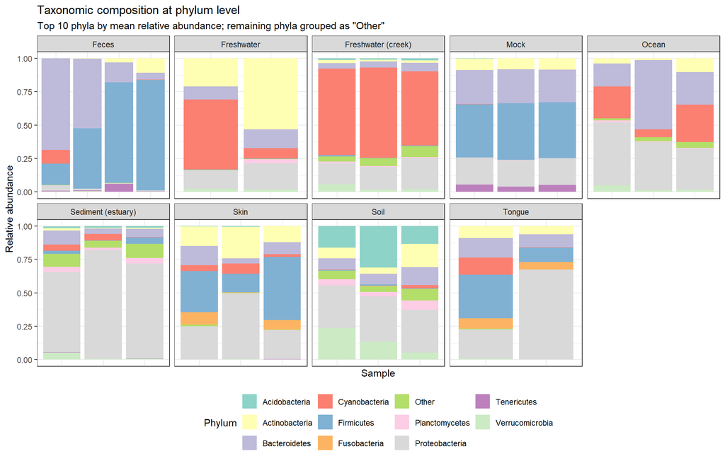

```r
ggplot(phylum_long, aes(x = SampleID, y = RelAbundance, fill = Phylum)) +
  geom_col() +
  facet_wrap(~ SampleType, scales = "free_x", nrow = 2) +
  scale_fill_brewer(palette = "Set3") +
  theme_bw() +
  theme(
    axis.text.x  = element_blank(),
    axis.ticks.x = element_blank(),
    legend.position = "bottom"
  ) +
  labs(
    title    = "Taxonomic composition at phylum level",
    subtitle = "Top 10 phyla by mean relative abundance; remaining phyla grouped as \"Other\"",
    x = "Sample",
    y = "Relative abundance",
    fill = "Phylum"
  )
```

### Dominant phyla by sample type

```r
phylum_long %>%
  group_by(SampleType, Phylum) %>%
  summarise(MeanRelAbundance = mean(RelAbundance), .groups = "drop") %>%
  group_by(SampleType) %>%
  slice_max(MeanRelAbundance, n = 3) %>%
  arrange(SampleType, desc(MeanRelAbundance))
```

```
## # A tibble: 27 × 3
## # Groups:   SampleType [9]
##    SampleType         Phylum         MeanRelAbundance
##    <fct>              <chr>                     <dbl>
##  1 Feces              Firmicutes               0.548
##  2 Feces              Bacteroidetes            0.352
##  3 Feces              Actinobacteria           0.0347
##  4 Freshwater         Actinobacteria           0.371
##  5 Freshwater         Cyanobacteria            0.302
##  6 Freshwater         Proteobacteria           0.167
##  7 Freshwater (creek) Cyanobacteria            0.626
##  8 Freshwater (creek) Proteobacteria           0.186
##  9 Freshwater (creek) Other                    0.0597
## 10 Mock               Firmicutes               0.414
## # ℹ 17 more rows
```

This table lists the three most abundant phyla within each `SampleType`, providing a compact, text-searchable complement to the stacked bar chart above — useful for identifying, for example, whether Soil and Sediment share dominant phyla (suggesting shared environmental drivers) or diverge entirely from host-associated types like Feces and Skin.

**Result:** At the phylum level, sample types showed distinct dominant taxa. Feces samples were dominated by Firmicutes (mean relative abundance 54.8%) and Bacteroidetes (35.2%), together accounting for about 90% of the community on average. Freshwater creek samples were dominated by Cyanobacteria (62.6%), with Proteobacteria as the second most abundant phylum (18.6%). In contrast, non-creek freshwater samples showed a more balanced composition, with Actinobacteria (37.1%), Cyanobacteria (30.2%), and Proteobacteria (16.7%) as the top three phyla. Mock-community samples were dominated by a small set of phyla, including Firmicutes (41.4%), consistent with their controlled composition. These patterns connect directly to earlier results: the Freshwater (creek) group’s high Observed richness paired with low Shannon diversity (section 9) is explained by this single-phylum dominance, and the tight beta-diversity clustering of creek and Mock samples (sections 10–11) is consistent with each being controlled by a small number of dominant phyla rather than a broad, even community.

# Interpretation and Limitations

The analysis followed a standard downstream microbiome workflow: sequencing-depth assessment, filtering decisions, alpha diversity (within-sample richness and evenness), beta diversity (between-sample compositional dissimilarity), and taxonomic-composition visualisation to identify the dominant phyla underlying the observed diversity patterns. Read together rather than as separate results: `SampleType` was found to be a strong driver of both within-sample diversity (section 9, Kruskal-Wallis p < 0.01 for all metrics) and between-sample composition (section 11, PERMANOVA R² = 0.73), and section 12 identifies the specific phyla responsible for these differences — most notably, Cyanobacteria dominance explaining the richness/evenness mismatch seen in Freshwater (creek) samples back in section 9.

This analysis has several important limitations:

- **Dispersion estimates for n = 2 groups (`Freshwater`, `Tongue`) are not informative.** With only two samples, distance-to-centroid is mathematically fixed at zero range regardless of true biological variability, so `betadisper()` results for these groups cannot be used to claim they are “tightly clustered.” Samples were retained (removing them would only shrink already-small groups further), but dispersion conclusions in section 11 rely on the n >= 3 groups only.
- **Processed data only:** the analysis begins with a preprocessed 16S feature table and does not reproduce upstream steps such as primer trimming, denoising, chimera removal, or taxonomy assignment. Conclusions therefore depend on the original processing choices.
- **Compositional data:** sequencing data provide relative, not absolute, microbial abundances. An increase in the relative abundance of one taxon may reflect either a true increase or a decrease in other taxa. This limits causal or quantitative interpretations.
- **Heterogeneous dataset:** GlobalPatterns combines very different environments (soil, water, human-associated samples, mock communities). Sample-type groups have small and unequal sizes, with some containing only two or three samples. Results are therefore descriptive and exploratory rather than confirmatory.
- **Rarefaction trade-offs:** alpha diversity was calculated from a rarefied table to standardise sequencing depth. Rarefaction discards reads from deeper samples and can reduce power, but it simplifies interpretation and is widely used for diversity comparisons. As shown in section 7, several low-depth samples had not clearly plateaued, so absolute richness values should be read as conservative estimates.
- **No differential-abundance testing:** the analysis focuses on diversity and composition patterns and does not test specific taxa for differential abundance between groups.

These limitations should be considered when interpreting the patterns described above.

# Reproducibility Information

This report was generated using R and the package versions listed below. Recording session information supports reproducibility and debugging.

[session information not shown]